# ‘compositions’ v2.0: R classes for compositional analysis

## The “compositions” package

The package “compositions” was released in 2005 to enable R users the analysis of compositional data in R. The main goals were twofold: to provide functions for the logratio analysis of compositions, and the facilitation of the comparison of results and interpretation among several analysis paradigms, in a transparent and consistent way. These paradigms correspond to different statistical scales for the data, thus for different geometries of the underlying sample space (the *simplex*). Each geometry was encoded in an S3 class. The following table summarizes these classes. Details on how to choose a class, and how to work with them can be found in UsingCompositions.pdf. Readers new to “compositions” are recommended to start there, as this vignette rather focuses on what has changed and how to do certain advanced analysis with the new functionality.

[output not shown]

In this table, the first three columns correspond to three binary questions that guide you in choosing the right geometry for your data

- are your data inherently counts, or can they be understood to be continuous data (even if they are discretized)?
- do your data carry information about a total sum, or is their sum irrelevant/a non-informative artifact?
- is the scale of your data a relative one (also know as *ratio scale*) or rather an absolute one (aka. *interval scale*)?

## Compositional classes, old and new

Once you have chosen your geometry (or a couple of them that you want to compare), you can load “compositions” with

```r
library(compositions)
```

and load your data with any data reading function (`read.csv()`, `read_delim()`, `read_excel()`, etc). Here we use for illustration purposes the data set “Hydrochem”

```r
data("Hydrochem")
dim(Hydrochem)
```

```
#> [1] 485  19
```

```r
colnames(Hydrochem)
```

```
#>  [1] "Code"     "Site"     "Location" "River"    "Date"     "H"
#>  [7] "Na"       "K"        "Mg"       "Ca"       "Sr"       "Ba"
#> [13] "NH4"      "Cl"       "NO3"      "PO4"      "SO4"      "HCO3"
#> [19] "TOC"
```

having 5 descriptive variables and 14 chemical components (from `H` to `TOC`). These last form a composition, which we preliminarily consider of an *aplus* geometry

```r
xp = aplus(Hydrochem[, c("Ca","K", "Na", "Mg")])
summary(xp)
```

```
#>             Ca        K       Na      Mg
#> Min.     40.39   0.0251    2.233   4.545
#> 1st Qu.  87.13   3.2230   30.360  20.430
#> Median  104.70  13.3700  135.100  34.260
#> Mean    119.30  10.1600   90.300  32.110
#> 3rd Qu. 170.10  32.6200  227.000  58.110
#> Max.    441.50 217.6000 1121.000 190.700
#> attr(,"class")
#> [1] "summary.aplus" "matrix"        "array"
```

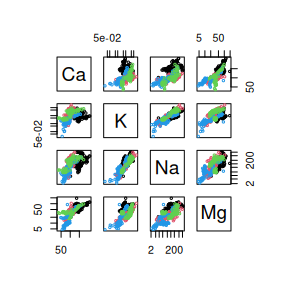

```r
plot(xp, col=Hydrochem$River, cex=0.5)
```

The object is of course an “aplus” object

```r
is.aplus(xp)    # check with S3 paradigm
```

```
#> [1] TRUE
```

```r
is(xp, "aplus") # check with S4 paradigm
```

```
#> [1] TRUE
```

but it is also an amounts object

```r
is(xp, "amounts") # only S4 paradigm
```

```
#> [1] TRUE
```

The “amounts” class is an abstract superclass, that cannot be created directly. Also objects of class “rplus” and “ccomp” are amounts

```r
is(rplus(xp), "amounts")
```

```
#> [1] TRUE
```

```r
is(ccomp(xp), "amounts")
```

```
#> [1] TRUE
```

If we consider the total sum of each row to be irrelevant, the appropriate class is an “acomp”

```r
xc = acomp(Hydrochem[, c("Ca","K", "Na", "Mg")])
summary(xc)
```

```
#> $mean
#>           Ca            K           Na           Mg
#> "0.47366650" "0.04034558" "0.35849821" "0.12748971"
#> attr(,"class")
#> [1] "acomp"
#>
#> $mean.ratio
#>            Ca         K        Na        Mg
#> Ca 1.00000000 11.740233 1.3212521 3.7153311
#> K  0.08517718  1.000000 0.1125405 0.3164614
#> Na 0.75685786  8.885688 1.0000000 2.8119776
#> Mg 0.26915501  3.159943 0.3556216 1.0000000
#>
#> $variation
#>           Ca        K        Na        Mg
#> Ca 0.0000000 1.697259 1.1117720 0.2195639
#> K  1.6972588 0.000000 0.4538740 1.1885007
#> Na 1.1117720 0.453874 0.0000000 0.7442923
#> Mg 0.2195639 1.188501 0.7442923 0.0000000
#>
#> $expsd
#>          Ca        K       Na       Mg
#> Ca 1.000000 3.679544 2.870270 1.597718
#> K  3.679544 1.000000 1.961485 2.974821
#> Na 2.870270 1.961485 1.000000 2.369606
#> Mg 1.597718 2.974821 2.369606 1.000000
#>
#> $invexpsd
#>           Ca         K        Na        Mg
#> Ca 1.0000000 0.2717728 0.3483993 0.6258926
#> K  0.2717728 1.0000000 0.5098179 0.3361547
#> Na 0.3483993 0.5098179 1.0000000 0.4220110
#> Mg 0.6258926 0.3361547 0.4220110 1.0000000
#>
#> $min
#>              Ca         K          Na          Mg
#> Ca 1.0000000000 0.4980473 0.146331281 0.853172522
#> K  0.0004626728 1.0000000 0.008240315 0.005522552
#> Na 0.0381578947 1.7109562 1.000000000 0.259131129
#> Mg 0.0806127186 0.4801286 0.053971402 1.000000000
```

[output cut: 24 more lines]

```
#> Ca 1.000000 2161.3546 26.2068966 12.404990
#> K  2.007841    1.0000  0.5844685  2.082775
#> Na 6.833809  121.3546  1.0000000 18.528331
#> Mg 1.172096  181.0757  3.8590501  1.000000
#>
#> $missingness
#>         missingType
#> variable NMV BDL MAR MNAR  SZ Err
#>       Ca 485   0   0    0   0   0
#>       K  485   0   0    0   0   0
#>       Na 485   0   0    0   0   0
#>       Mg 485   0   0    0   0   0
#>
#> attr(,"class")
#> [1] "summary.acomp"
```

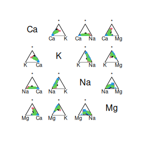

```r
plot(xc, col=Hydrochem$River, cex=0.5)
```

This can be thus checked

```r
is.acomp(xc)    # check with S3 paradigm
```

```
#> [1] TRUE
```

```r
is(xc, "acomp") # check with S4 paradigm
```

```
#> [1] TRUE
```

There is also an abstract superclass for compositional objects, i.e. those where the total is irrelevant or an artifact

```r
is(xc, "compositional")
```

```
#> [1] TRUE
```

that contains objects of class “acomp”, “rcomp” and “ccomp”

```r
is(rcomp(xc), "compositional")
```

```
#> [1] TRUE
```

```r
is(ccomp(xc), "compositional")
```

```
#> [1] TRUE
```

Additionally, all comopostional classes have natural ways to be automatically converted to “data.frame” and to “structure” classes. This works like this

```r
as(xc, "data.frame")
as(xc, "structure")
```

and it allows S4 classes with slots expecting a “data.frame” or one of “vector”, “matrix” or “array” to accept a compositional object. This will be discussed in the last section of this vignette.

## Subsetting and transformations

Compositional data sets react now to the dollar notation. Since compositions v2 you can extract one particular variable with

```r
summary(xp$Ca)
```

```
#>    Min. 1st Qu.  Median    Mean 3rd Qu.    Max.
#>   40.39   87.13  104.70  132.12  170.10  441.50
```

As discussed in UsingCompositions.pdf, the key idea of compositional analysis is to transform the data prior to the analysis. All transformations are now accessible using the dollar notation

```r
summary(xp$clr)
```

```
#>                 Ca          K         Na          Mg
#> Min.    -0.5765232 -4.4190306 -0.7626504 -1.14624527
#> 1st Qu.  0.4801820 -1.9501308  0.3878456 -0.69086350
#> Median   0.8936557 -1.5989396  0.8498314 -0.36473684
#> Mean     1.0135173 -1.4495044  0.7349375 -0.29895048
#> 3rd Qu.  1.5489812 -0.7802982  1.0572174  0.03228459
#> Max.     3.2594599  0.1205369  1.8932905  1.36923306
#> attr(,"class")
#> [1] "summary.rmult" "matrix"        "array"
```

This includes each of `alr`, `ilr`, `clr`, `log`, `ilt`, `iit`, `apt`, `ipt`, `cpt`, their generic versions `cdt` and `idt`, as well as all their inverses (e.g. `cptInv` or `alrInv`). Also `raw`, `clo`, `unclass` and `pwlr` resp. `pwlrInv` (pairwise logratio and its inverse) work with this trick

```r
summary(xp)
```

```
#>             Ca        K       Na      Mg
#> Min.     40.39   0.0251    2.233   4.545
#> 1st Qu.  87.13   3.2230   30.360  20.430
#> Median  104.70  13.3700  135.100  34.260
#> Mean    119.30  10.1600   90.300  32.110
#> 3rd Qu. 170.10  32.6200  227.000  58.110
#> Max.    441.50 217.6000 1121.000 190.700
#> attr(,"class")
#> [1] "summary.aplus" "matrix"        "array"
```

```r
summary(cdt(xp))
```

```
#>               Ca         K       Na       Mg
#> Min.    3.698582 -3.684887 0.803346 1.514028
#> 1st Qu. 4.467401  1.170313 3.413126 3.017004
#> Median  4.651099  2.593013 4.906015 3.533978
#> Mean    4.781715  2.318693 4.503135 3.469247
#> 3rd Qu. 5.136386  3.484926 5.424950 4.062338
#> Max.    6.090178  5.382888 7.022422 5.250702
#> attr(,"class")
#> [1] "summary.rmult" "matrix"        "array"
```

```r
summary(xp$cdt)
```

```
#>               Ca         K       Na       Mg
#> Min.    3.698582 -3.684887 0.803346 1.514028
#> 1st Qu. 4.467401  1.170313 3.413126 3.017004
#> Median  4.651099  2.593013 4.906015 3.533978
#> Mean    4.781715  2.318693 4.503135 3.469247
#> 3rd Qu. 5.136386  3.484926 5.424950 4.062338
#> Max.    6.090178  5.382888 7.022422 5.250702
#> attr(,"class")
#> [1] "summary.rmult" "matrix"        "array"
```

```r
summary(xp$cdt$cdtInv)
```

```
#>             Ca        K       Na      Mg
#> Min.     40.39   0.0251    2.233   4.545
#> 1st Qu.  87.13   3.2230   30.360  20.430
#> Median  104.70  13.3700  135.100  34.260
#> Mean    119.30  10.1600   90.300  32.110
#> 3rd Qu. 170.10  32.6200  227.000  58.110
#> Max.    441.50 217.6000 1121.000 190.700
#> attr(,"class")
#> [1] "summary.aplus" "matrix"        "array"
```

Another (potentially conflictive) novelty is the `[`-subsetting, in particular for closed classes (“acomp” and “rcomp”). In compositions-v1, subseting invariably destroyed the class, returning the selected rows or columns in a matrix, or even in a vector if only one row or one column was selected. From compositions-v2 on, the nature of the subsetting depends on class of the parent object and the number of selected elements:

- selecting rows returns an object of the same class as the parent object; if only one row is chosen, the output will be a vector of the parent class;

```r
xp0 = xp[1:5,]
xp0
```

```
#>   Ca      K       Na      Mg
#> 1 "279.1" "6.318" "159.0" "92.41"
#> 2 "300.3" "6.449" "179.2" "96.20"
#> 3 "305.1" "5.978" "186.0" "96.83"
#> 4 "343.4" "5.171" "181.1" "88.58"
#> 5 "369.0" "7.371" "151.0" "84.90"
#> attr(,"class")
#> [1] "aplus"
```

```r
xc0 = xc[1:5,]
xc0
```

```
#>   Ca          K             Na          Mg
#> 1 "0.5199058" "0.011769133" "0.2961843" "0.1721408"
#> 2 "0.5158473" "0.011077920" "0.3078250" "0.1652498"
#> 3 "0.5137159" "0.010065532" "0.3131798" "0.1630387"
#> 4 "0.5554378" "0.008363917" "0.2929231" "0.1432751"
#> 5 "0.6026743" "0.012038787" "0.2466228" "0.1386641"
#> attr(,"class")
#> [1] "acomp"
```

```r
xc[10,]
```

```
#>           Ca            K           Na           Mg
#> "0.52155495" "0.01018437" "0.30386080" "0.16439989"
#> attr(,"class")
#> [1] "acomp"
```

```r
xp0[,"Ca"]
```

```
#>     1     2     3     4     5
#> 279.1 300.3 305.1 343.4 369.0
```

```r
xp0[,c("Ca","K")]
```

```
#>   Ca      K
#> 1 "279.1" "6.318"
#> 2 "300.3" "6.449"
#> 3 "305.1" "5.978"
#> 4 "343.4" "5.171"
#> 5 "369.0" "7.371"
#> attr(,"class")
#> [1] "aplus"
```

- selecting two or more columns of objects of class “acomp” or “rcomp” returns the selected subcomposition, that is, another object of the parent class with the selected components reclosed to sum to 1

```r
xc0[,c("Ca","K")]
```

```
#>   Ca          K
#> 1 "0.9778640" "0.02213595"
#> 2 "0.9789763" "0.02102370"
#> 3 "0.9807830" "0.01921705"
#> 4 "0.9851651" "0.01483485"
#> 5 "0.9804156" "0.01958440"
#> attr(,"class")
#> [1] "acomp"
```

- selecting one single column returns that individual column as a vector; the same happens with the dollar notation; both destroy the class

```r
xc0$Ca
```

```
#>         1         2         3         4         5
#> 0.5199058 0.5158473 0.5137159 0.5554378 0.6026743
```

```r
xc0[,"Ca"]
```

```
#>         1         2         3         4         5
#> 0.5199058 0.5158473 0.5137159 0.5554378 0.6026743
```

```r
xp0[,"Ca"]
```

```
#>     1     2     3     4     5
#> 279.1 300.3 305.1 343.4 369.0
```

- you can override this special bevavior and return to the behavior of compositions v1 by specifying the extra argument `drop=TRUE` in the subsetting, or globally by calling `setStickyClassOption(FALSE)`

```r
xc0[,c("Ca","K"), drop=TRUE]
```

```
#>          Ca           K
#> 1 0.5199058 0.011769133
#> 2 0.5158473 0.011077920
#> 3 0.5137159 0.010065532
#> 4 0.5554378 0.008363917
#> 5 0.6026743 0.012038787
```

```r
xp0[,"Ca", drop=TRUE]
```

```
#>     1     2     3     4     5
#> 279.1 300.3 305.1 343.4 369.0
```

You can check which is the current status of sticky classes with `getStickyClassOption()`.

## Compositions as columns

Matrix-like compositions can be embedded in other data containers, typically “data.frame”s or tibbles. For this, we just need to define an extra column

```r
Hydrochem$comp <- xc
head(Hydrochem)
```

```
#>      Code Site Location River       Date            H    Na     K    Mg    Ca
#> 1 9535612   95    Anoia Anoia 01.07.1997 7.943282e-09 159.0 6.318 92.41 279.1
#> 2 9535643   95    Anoia Anoia 01.08.1997 5.011872e-09 179.2 6.449 96.20 300.3
#> 3 9535674   95    Anoia Anoia 01.09.1997 7.943282e-09 186.0 5.978 96.83 305.1
#> 4 9535704   95    Anoia Anoia 01.10.1997 6.165950e-09 181.1 5.171 88.58 343.4
#> 5 9535735   95    Anoia Anoia 01.11.1997 1.202264e-08 151.0 7.371 84.90 369.0
#> 6 9535765   95    Anoia Anoia 01.12.1997 1.028016e-08 170.1 6.475 89.82 337.6
#>        Sr       Ba        NH4       Cl       NO3       PO4      SO4     HCO3
#> 1 8.58366 0.049900 0.22341340 345.9561 16.965779 0.4014300 730.6014 349.5047
#> 2 7.29700 0.054983 0.02694842 280.2735  8.647828 0.5218775 773.2336 314.6050
#> 3 7.34100 0.057367 0.07923994 300.2572 11.394282 0.5084960 884.5392 342.4435
#> 4 7.63000 0.059473 0.02231826 297.9269 11.293516 0.4014442 757.7849 335.2200
#> 5 8.24600 0.053410 0.46398830 229.2619  9.547616 0.4415887 616.2988 308.6500
#> 6 7.57200 0.050168 0.09921348 267.8800 13.253693 0.6958367 881.1794 334.1700
#>     TOC      comp.1      comp.2      comp.3      comp.4
#> 1 3.022 0.519905817 0.011769133 0.296184253 0.172140797
#> 2 3.039 0.515847317 0.011077920 0.307824973 0.165249790
#> 3 3.196 0.513715929 0.010065532 0.313179819 0.163038720
#> 4 3.871 0.555437840 0.008363917 0.292923101 0.143275142
#> 5 3.400 0.602674306 0.012038787 0.246622819 0.138664088
#> 6 3.625 0.558945024 0.010720287 0.281624848 0.148709840
```

```r
dim(Hydrochem)
```

```
#> [1] 485  20
```

This composition can be then recovered with the dollar notation, and also used in further calls to statistical methods, e.g.

```r
head(Hydrochem$comp)
```

```
#>   [,1]        [,2]          [,3]        [,4]
#> 1 "0.5199058" "0.011769133" "0.2961843" "0.1721408"
#> 2 "0.5158473" "0.011077920" "0.3078250" "0.1652498"
#> 3 "0.5137159" "0.010065532" "0.3131798" "0.1630387"
#> 4 "0.5554378" "0.008363917" "0.2929231" "0.1432751"
#> 5 "0.6026743" "0.012038787" "0.2466228" "0.1386641"
#> 6 "0.5589450" "0.010720287" "0.2816248" "0.1487098"
#> attr(,"class")
#> [1] "acomp"
```

```r
codalm = lm(alr(comp)~River, data=Hydrochem)
summary(codalm)
```

```
#> Response v1 :
#>
#> Call:
#> lm(formula = v1 ~ River, data = Hydrochem)
#>
#> Residuals:
#>      Min       1Q   Median       3Q      Max
#> -1.90144 -0.19728  0.06689  0.26947  0.82324
#>
#> Coefficients:
#>                     Estimate Std. Error t value Pr(>|t|)
#> (Intercept)          1.13957    0.03242  35.152   <2e-16 ***
#> RiverCardener        0.09677    0.05131   1.886   0.0599 .
#> RiverLowerLLobregat  0.01237    0.04652   0.266   0.7904
#> RiverUpperLLobregat  0.65173    0.04892  13.324   <2e-16 ***
#> ---
#> Signif. codes:  0 '***' 0.001 '**' 0.01 '*' 0.05 '.' 0.1 ' ' 1
#>
#> Residual standard error: 0.3877 on 481 degrees of freedom
#> Multiple R-squared:  0.3198, Adjusted R-squared:  0.3155
#> F-statistic: 75.38 on 3 and 481 DF,  p-value: < 2.2e-16
#>
#>
#> Response v2 :
#>
#> Call:
#> lm(formula = v2 ~ River, data = Hydrochem)
#>
#> Residuals:
#>     Min      1Q  Median      3Q     Max
#> -3.3186 -0.3621  0.1977  0.4878  1.6234
#>
#> Coefficients:
#>                     Estimate Std. Error t value Pr(>|t|)
#> (Intercept)         -1.68613    0.07202 -23.413   <2e-16 ***
#> RiverCardener        0.99021    0.11399   8.687   <2e-16 ***
#> RiverLowerLLobregat  1.38843    0.10334  13.435   <2e-16 ***
#> RiverUpperLLobregat -0.19421    0.10867  -1.787   0.0745 .
#> ---
#> Signif. codes:  0 '***' 0.001 '**' 0.01 '*' 0.05 '.' 0.1 ' ' 1
```

[output cut: 12 more lines]

```
#>     Min      1Q  Median      3Q     Max
#> -2.1345 -0.4578  0.2273  0.5083  1.7514
#>
#> Coefficients:
#>                     Estimate Std. Error t value Pr(>|t|)
#> (Intercept)          0.95089    0.06784  14.017  < 2e-16 ***
#> RiverCardener        0.21806    0.10738   2.031 0.042821 *
#> RiverLowerLLobregat  0.45005    0.09735   4.623 4.86e-06 ***
#> RiverUpperLLobregat -0.36803    0.10236  -3.595 0.000357 ***
#> ---
#> Signif. codes:  0 '***' 0.001 '**' 0.01 '*' 0.05 '.' 0.1 ' ' 1
#>
#> Residual standard error: 0.8112 on 481 degrees of freedom
#> Multiple R-squared:  0.1213, Adjusted R-squared:  0.1158
#> F-statistic: 22.13 on 3 and 481 DF,  p-value: 1.94e-13
```

The transformation can even be called with the dollar notation, and transformed data keep the information necessary to construct their back-transformation.

```r
codalm = lm(comp$idt~River, data=Hydrochem)
head(predict(codalm)$idtInv)
```

```
#>   [,1]        [,2]         [,3]        [,4]
#> 1 "0.4530465" "0.02685076" "0.3751471" "0.1449556"
#> 2 "0.4530465" "0.02685076" "0.3751471" "0.1449556"
#> 3 "0.4530465" "0.02685076" "0.3751471" "0.1449556"
#> 4 "0.4530465" "0.02685076" "0.3751471" "0.1449556"
#> 5 "0.4530465" "0.02685076" "0.3751471" "0.1449556"
#> 6 "0.4530465" "0.02685076" "0.3751471" "0.1449556"
#> attr(,"class")
#> [1] "acomp"
```

To recover the column names in the backtransformation you might need to make use of the `orig` argument of the explicit transformation (that is, without the dollar notation)

```r
head(idtInv(predict(codalm), orig=xc))
```

```
#>   Ca          K            Na          Mg
#> 1 "0.4530465" "0.02685076" "0.3751471" "0.1449556"
#> 2 "0.4530465" "0.02685076" "0.3751471" "0.1449556"
#> 3 "0.4530465" "0.02685076" "0.3751471" "0.1449556"
#> 4 "0.4530465" "0.02685076" "0.3751471" "0.1449556"
#> 5 "0.4530465" "0.02685076" "0.3751471" "0.1449556"
#> 6 "0.4530465" "0.02685076" "0.3751471" "0.1449556"
#> attr(,"class")
#> [1] "acomp"
```

Note as well the existence of the new function `backtransform`, which will take an “rmult” object and return its expression in the appropriate original components. This can even be allowed to be controlled by a third object through an extra argument `as`

```r
head(backtransform(idt(xp)))
```

```
#>   Ca      K       Na      Mg
#> 1 "279.1" "6.318" "159.0" "92.41"
#> 2 "300.3" "6.449" "179.2" "96.20"
#> 3 "305.1" "5.978" "186.0" "96.83"
#> 4 "343.4" "5.171" "181.1" "88.58"
#> 5 "369.0" "7.371" "151.0" "84.90"
#> 6 "337.6" "6.475" "170.1" "89.82"
#> attr(,"class")
#> [1] "aplus"
```

```r
head(backtransform(predict(codalm), as=codalm$residuals))
```

```
#>   [,1]        [,2]         [,3]        [,4]
#> 1 "0.4530465" "0.02685076" "0.3751471" "0.1449556"
#> 2 "0.4530465" "0.02685076" "0.3751471" "0.1449556"
#> 3 "0.4530465" "0.02685076" "0.3751471" "0.1449556"
#> 4 "0.4530465" "0.02685076" "0.3751471" "0.1449556"
#> 5 "0.4530465" "0.02685076" "0.3751471" "0.1449556"
#> 6 "0.4530465" "0.02685076" "0.3751471" "0.1449556"
#> attr(,"class")
#> [1] "acomp"
```

In the case of tibbles, the column names of the embedded object are even preserved, so that

```r
tbHydro = tibble::as_tibble(Hydrochem)
tbHydro$comp = xc
tbHydro$comp$Ca
```

would return the same as `xc$Ca`. This is not included here to reduce the dependencies of this package. Note that this trick does not work with “data.frame” objects, because `[<-` takes care of removing the column names of the composition before attaching it.

This property of *self-back-transformability* is the single most important addition to “compositions” v2, and will experiment improvements in the future. In particular, we strive to make the recovery of column names automatic in the near future.

## Embedding in S4 objects

The final addition to compositions v2 is the ability of compositional data to *fake* to be “data.frame”s or “structure”s themselves. This allows them to be embedded in S3 elements and S4 classes in slots expecting one of these objects, keeping their additional attributes (hence their compositional nature, backtransformability and so on). This is an example of how this could work, for instance in a spatial data frame of package “sp”. As before, this is not actually included here to avoid including one extra package. Readers are invited to check how it works. Packages “gstat” and “sp” are necessary

```r
data("jura", package="gstat")
coords = jura.pred[, 1:2]
compo = jura.pred[, 7:13]
xc = cdt(acomp(compo))
spcompo = SpatialPointsDataFrame(coords=coords, data=xc)
summary(spcompo@data)
class(spcompo@data)
```

For an S4 class to admit compositional classes in their slots for “data.frame”, “vector”, “matrix” or “array” objects, though, there is a condition: validity checks must be made after `as(x,"data.frame")`, `as(x,"matrix")` or equivalent is applied.